# Proyecto ATOYAC

Rosaisela Perez

2025-05-22

##* Semana 1: Un vistazo al dataset a utilizar Carga de datos

```r
# Cargar dataset elegido
data <- read_csv("CALIDAD_AGUA.csv")
```

Exploración inicial de los datos.

```r
head(data)
```

```
## # A tibble: 6 × 9
##   ESTADO         MUNICIPIO  SUBTIPO LONGITUD LATITUD   DQO   SST E.COLI SEMAFORO
##   <chr>          <chr>      <chr>      <dbl>   <dbl> <dbl> <dbl>  <dbl> <chr>
## 1 AGUASCALIENTES SAN JOSE … PRESA      -102.    22.2  25.7   9       10 Verde
## 2 AGUASCALIENTES SAN JOSE … PRESA      -102.    22.1  26.3   9        2 Verde
## 3 AGUASCALIENTES SAN JOSE … PRESA      -102.    22.1  29.0   9        2 Verde
## 4 AGUASCALIENTES SAN JOSE … PRESA      -102.    22.1  30.6   9        2 Verde
## 5 AGUASCALIENTES SAN JOSE … PRESA      -102.    22.2  34.2  13.2      2 Amarillo
## 6 AGUASCALIENTES JESUS MAR… RIO        -102.    22.0 712.  229.  241960 Rojo
```

```r
str(data)
```

```
## spc_tbl_ [4,202 × 9] (S3: spec_tbl_df/tbl_df/tbl/data.frame)
##  $ ESTADO   : chr [1:4202] "AGUASCALIENTES" "AGUASCALIENTES" "AGUASCALIENTES" "AGUASCALIENTES" ...
##  $ MUNICIPIO: chr [1:4202] "SAN JOSE DE GRACIA" "SAN JOSE DE GRACIA" "SAN JOSE DE GRACIA" "SAN JOSE DE GRACIA" ...
##  $ SUBTIPO  : chr [1:4202] "PRESA" "PRESA" "PRESA" "PRESA" ...
##  $ LONGITUD : num [1:4202] -102 -102 -102 -102 -102 ...
##  $ LATITUD  : num [1:4202] 22.2 22.1 22.1 22.1 22.2 ...
##  $ DQO      : num [1:4202] 25.7 26.3 29 30.6 34.2 ...
##  $ SST      : num [1:4202] 9 9 9 9 13.2 ...
##  $ E.COLI   : num [1:4202] 10 2 2 2 2 ...
##  $ SEMAFORO : chr [1:4202] "Verde" "Verde" "Verde" "Verde" ...
##  - attr(*, "spec")=
##   .. cols(
##   ..   ESTADO = col_character(),
##   ..   MUNICIPIO = col_character(),
##   ..   SUBTIPO = col_character(),
##   ..   LONGITUD = col_double(),
##   ..   LATITUD = col_double(),
##   ..   DQO = col_double(),
##   ..   SST = col_double(),
##   ..   E.COLI = col_double(),
##   ..   SEMAFORO = col_character()
##   .. )
##  - attr(*, "problems")=<externalptr>
```

```r
dim(data)
```

```
## [1] 4202    9
```

```r
summary(data)
```

```
##     ESTADO           MUNICIPIO           SUBTIPO             LONGITUD
##  Length:4202        Length:4202        Length:4202        Min.   :-114.28
##  Class :character   Class :character   Class :character   1st Qu.:-103.48
##  Mode  :character   Mode  :character   Mode  :character   Median :-100.81
##                                                           Mean   :-100.43
##                                                           3rd Qu.: -99.04
##                                                           Max.   : -86.73
##                                                           NA's   :2281
##     LATITUD           DQO               SST              E.COLI
##  Min.   :16.42   Min.   :   9.00   Min.   :   9.00   Min.   :      2
##  1st Qu.:18.61   1st Qu.:  16.66   1st Qu.:   9.00   1st Qu.:     20
##  Median :20.06   Median :  31.29   Median :  20.00   Median :    173
##  Mean   :20.69   Mean   :  86.14   Mean   :  44.65   Mean   :   8532
##  3rd Qu.:21.75   3rd Qu.:  60.80   3rd Qu.:  46.38   3rd Qu.:   2400
##  Max.   :31.78   Max.   :7773.60   Max.   :2300.00   Max.   :2419600
##  NA's   :2281    NA's   :2672      NA's   :2284      NA's   :2675
##    SEMAFORO
##  Length:4202
##  Class :character
##  Mode  :character
##
##
##
##
```

##* Semana 2: Definición del Problema y selección del dataset

Para realizar ésta actividad retomé un tema de un proyecto de investigación que estoy llevando a cabo en una clase llamada: Sistemas de información geográfica que lleva por título: “Comparación de parámetros de calidad del agua en el Río Atoyac en el Municipio de San Martín Texmelucan; Puebla.” La base de datos que encontré y descargué lleva por nombre “Resultados Cuenca del Río Alto Atoyac”,del la :¿siguiente página de CONAGUA: <https://app.conagua.gob.mx/ICA/Contenido?n1=5&n2=14&n3=8<

Al observar la base de datos original me percaté que la estructura era complicada y, para el nivel en que me encuentro me iba a ser muy complicado la manipulación de los datos. Es por ello que tomé la desición de hacer un segundo documento con la información del original, donde rescaté datos puntuales y más sencillos los cuales fueron: Nombre del Estado Nombre del Municipio Subtipo (de cuerpo de agua) Coordenadas Lectura Solidos Suspendidos Totales (mg/L) Lectura Demanda Química de Oxígeno (mg/L) Lectura E. COLI (NMP/100mL) CLASIFICACIÓN SEGÚN SEMAFORO DE CALIDAD

#* Preguntas de análisis ¿Cómo es la calidad del agua del Río Atoyac en el Estado de Puebla?

¿Cómo se compara la calidad de Agua del Municipio de San Martín T. con sus municipios colindantes?

## *Semana 3: Análisis*

Limpieza de datos y filtrado

```r
#Saber cuántos datos nulos hay por columna
colSums(is.na(data))
```

```
##    ESTADO MUNICIPIO   SUBTIPO  LONGITUD   LATITUD       DQO       SST    E.COLI
##      2281      2281      2281      2281      2281      2672      2284      2675
##  SEMAFORO
##      2281
```

```r
#Eliminamos datos nulos
data_limpia<- na.omit(data)
colSums(is.na(data_limpia))
```

```
##    ESTADO MUNICIPIO   SUBTIPO  LONGITUD   LATITUD       DQO       SST    E.COLI
##         0         0         0         0         0         0         0         0
##  SEMAFORO
##         0
```

```r
#Filtramos datos únicamente de Puebla
datos_Puebla<- data_limpia[data_limpia$ESTADO %in% c("PUEBLA"),]

#Filtrar unicamente datos del municipio de San Martín Texmelucan:
datos_sm<- datos_Puebla[datos_Puebla$MUNICIPIO %in% c("SAN MARTIN TEXMELUCAN"),]

#Seleccionar únicamente columnas de importancia

Datos_estudio<- datos_sm%>%
  select(SST, DQO,E.COLI, SEMAFORO, MUNICIPIO)

#convertir datos numéricos necesarios
Semaforo<-as.numeric(Datos_estudio$SEMAFORO)
#corroborar si el dato con el que trabajaremos la estadística es numérico
is.numeric(Datos_estudio$DQO)
```

```
## [1] TRUE
```

```r
is.numeric(Datos_estudio$SST)
```

```
## [1] TRUE
```

```r
is.numeric(Datos_estudio$E.COLI)
```

```
## [1] TRUE
```

Medidas de tendencia central

```r
#Calcular la media de los parámetros de estudio
media_DQO<- mean(Datos_estudio$DQO)
cat("El valor promedio de DQO en Río Atoyac a lo largo del municipio de San Martin Texmelucan es:", media_DQO)
```

```
## El valor promedio de DQO en Río Atoyac a lo largo del municipio de San Martin Texmelucan es: 277.1552
```

```r
media_SST<- mean(Datos_estudio$SST)
cat("El valor promedio de los Sólidos Suspendidos Totales en el Río Atoyac a lo largo del municipio de San Martin Texmelucan es:", media_SST)
```

```
## El valor promedio de los Sólidos Suspendidos Totales en el Río Atoyac a lo largo del municipio de San Martin Texmelucan es: 93.35583
```

```r
media_E.COLI<- mean(Datos_estudio$E.COLI)
cat("El valor promedio de E.Coli en Río Atoyac a lo largo del municipio de San Martin Texmelucan es:", media_E.COLI)
```

```
## El valor promedio de E.Coli en Río Atoyac a lo largo del municipio de San Martin Texmelucan es: 9966.667
```

```r
#Calcular la mediana del los parámetros de estudio
mediana_DQO<- median(Datos_estudio$DQO)
cat("La mediana del valor de DQO en Río Atoyac a lo largo del municipio de San Martin Texmelucan es:", mediana_DQO)
```

```
## La mediana del valor de DQO en Río Atoyac a lo largo del municipio de San Martin Texmelucan es: 182.39
```

```r
mediana_SST<- median(Datos_estudio$SST)
cat("La mediana del valor de  los Sólidos Suspendidos Totales en el Río Atoyac a lo largo del municipio de San Martin Texmelucan es:", mediana_SST)
```

```
## La mediana del valor de  los Sólidos Suspendidos Totales en el Río Atoyac a lo largo del municipio de San Martin Texmelucan es: 84.175
```

```r
mediana_E.COLI<- median(Datos_estudio$E.COLI)
cat("La mediana del valor de  E.Coli en Río Atoyac a lo largo del municipio de San Martin Texmelucan es:", mediana_E.COLI)
```

```
## La mediana del valor de  E.Coli en Río Atoyac a lo largo del municipio de San Martin Texmelucan es: 7800
```

```r
#Calcular varianza

var_DQO<- var(Datos_estudio$DQO)
var_DQO
```

```
## [1] 29611.74
```

```r
var_SST<- var(Datos_estudio$SST)
var_SST
```

```
## [1] 1723.109
```

```r
var_E.COLI<- var(Datos_estudio$E.COLI)
var_E.COLI
```

```
## [1] 86553667
```

## *Visualización de datos*

En primera estancia se plantea un gráfico de barras donde se observa la calidad de agua del Río Atoyac a lo largo del Estado de Puebla según el semáforo de la CONAGUA. Aquí nos podemos dar cuenta que de los 108 datos totales de punto de muestreo que se encuentran a lo largo del Río Atoyac: 88 miden una mala calidad, tan sólo 11 una calidad media y únicamente 9 corresponden a una calidad buena.

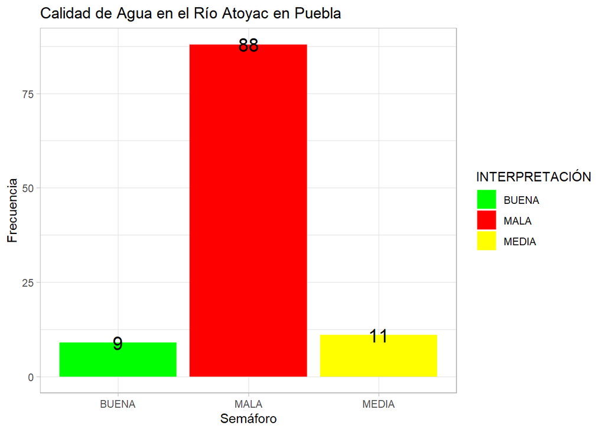

```r
datos_Puebla$INTERPRETACIÓN <- recode(datos_Puebla$SEMAFORO,
                                     "Rojo" = "MALA",
                                     "Amarillo" = "MEDIA",
                                     "Verde" = "BUENA")

# Gráfico con etiquetas
ggplot(datos_Puebla, aes(x = INTERPRETACIÓN, fill = INTERPRETACIÓN)) +
  geom_bar() +
  geom_text(stat = "count", aes(label = ..count..), size = 5.5) +
  scale_fill_manual(values = c("MALA" = "red", "MEDIA" = "yellow", "BUENA" = "green")) +
  labs(title = "Calidad de Agua en el Río Atoyac en Puebla",
       x = "Semáforo",
       y = "Frecuencia") +
  theme_light()
```

Haciendo la comparación con dos de los municipios colindantes de San Martín Texmelucan y los valores mayores de DQO medidos en cada uno de éstos se realizó un gráfico de barras en el cual destaca la gran varianza entre las medidas de los 3 municipios, siendo la de San Martín Texmelucan medidas ligeramente por arriba de 500 mg/L.

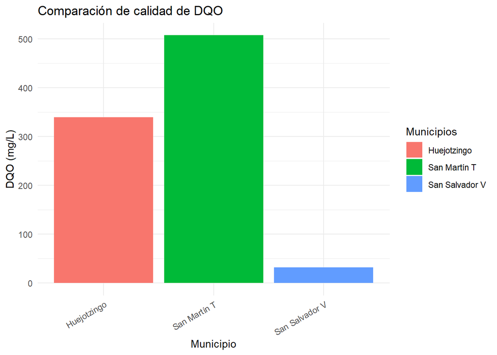

```r
municipios <- c("San Martín T", "Huejotzingo", "San Salvador V")
DQO <- c(507.30, 339, 32.0)

df <- data.frame(Municipios = municipios, DQO = DQO)

ggplot(df, aes(x = Municipios, y = DQO, fill = Municipios)) +
  geom_bar(stat = "identity") +
  labs(title = "Comparación de calidad de DQO", x = "Municipio", y = "DQO (mg/L)") +
  theme_minimal() +
  theme(axis.text.x = element_text(angle = 30, hjust = 1))
```

En el siguiente gráfico de pastel podemos observar que en cuanto al porcentage de E.Coli; el municipio de San Martín Texmelucan es el mayor, desués sigue el municipio de San Salvador y por último Huejotzingo.

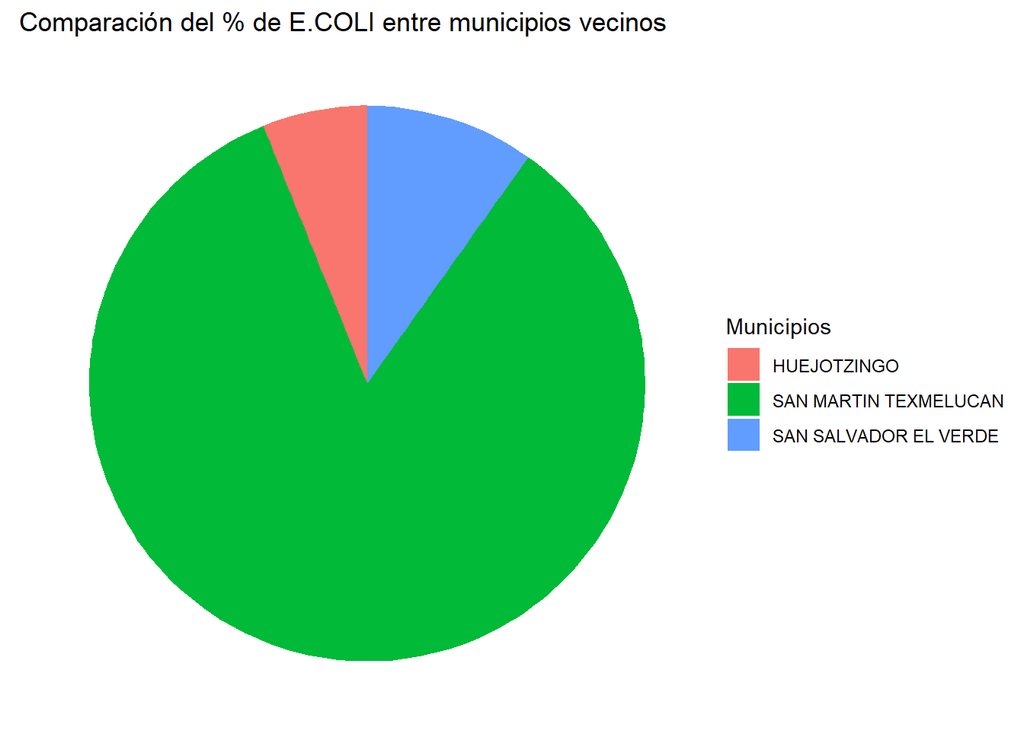

```r
Municipios<- datos_Puebla[datos_Puebla$MUNICIPIO %in% c("SAN MARTIN TEXMELUCAN","HUEJOTZINGO", "SAN SALVADOR EL VERDE"),]

Municipios <- Municipios %>% arrange(desc(Municipios$E.COLI))

# Crear el gráfico circular simple
ggplot(Municipios, aes(x = "", y = Municipios$E.COLI, fill = MUNICIPIO)) +
  geom_bar(stat = "identity", width = 1) +
  coord_polar("y") +
  labs(title = "Comparación del % de E.COLI entre municipios vecinos", fill = "Municipios") +
  theme_void()
```

Por último comparamos el parámetro de SST (mg/L) Éste por medio del siguiente grafico de barras:

[figure not shown]

```r
ggplot(Municipios, aes(x = MUNICIPIO, y = SST, fill = MUNICIPIO)) +
  geom_bar(stat = "identity") +
  labs(title = "Comparación de calidad de DQO", x = "Municipio", y = "SST (mg/L)") +
  theme_minimal() +
  theme(axis.text.x = element_text(angle = 30, hjust = 1))
```

## *Conclusiones y Hallazgos*

De éste análsis se puede concluir lo siguiente: * La calidad de Agua en el Río Atoyac se encuentra altamente contaminada a lo largo del Estado de puebla; de los 108 puntos de muestreo ubicados a lo largo del Río, tan sólo 9 indican una calidad de agua buena, en comparación con las 88 que indican una pésima calidad. Ésto en porcentajes es: Calidad de Agua Buena:8.33% Calidad de Agua Media: 10.18% Calidad de Agua Mala: 81.48%

Evaluando los parámetros de forma individual podemos observar que ninguno se separa de los resultados generales, es decir, ningpun parámetro estudiado individualmente cambiaría la calidad de agua del municipio de San martín pues en base a la NOM-001-SEMARNAT-2021 que establece los límites máximos permisibles en cuerpos de agua: cada parámetro medido dentro del Muniipio de San Martín Texmelucan sobrepasa dichos límites evidenciando la pésima calidad del agua del Río Atoyac. Ésto puede deberse a su alta actividad industrial, especialmente la textilera.

Es por ello que las autoridades deben realizar trabajos de regulación de contaminantes así como tratamiento de aguas con la finalidad de cuidar la salud de los pobladores y por supuesto el medio ambiente.